# Course Project

Miguel González Lugo

7/19/2020

# Course Project 2

This r markdown performs an exploratory analysis on data from a personal monitoring device. This device tracked the steps of an anonimous person in intervals of 5 minutes.

## Reading and manipulationg the data

The data is read using read.csv, the “date” variable is change into a variable of class data using lubridate package

```r
library(lubridate)
actData <- read.csv("activity.csv")
actData$date <- ymd(actData$date)
```

## Histogram of the total number of steps taken each day

Grouping by date.

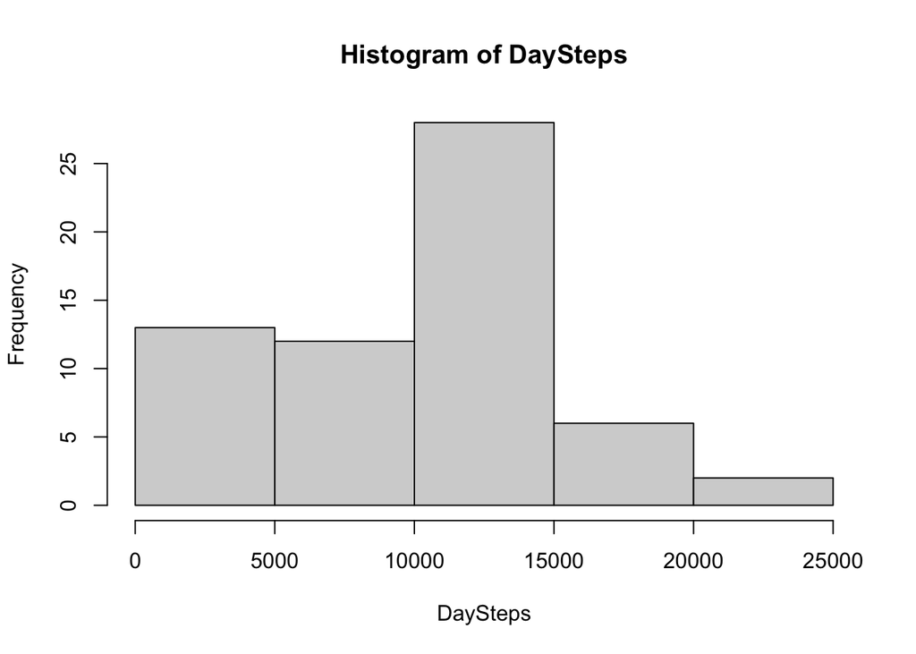

```r
DaySteps <- with(actData, tapply(steps, date, sum, na.rm = T))
hist(DaySteps)
```

## Mean and median number of steps taken each day

```r
sum <- summary(DaySteps)
sum
```

```
##    Min. 1st Qu.  Median    Mean 3rd Qu.    Max.
##       0    6778   10395    9354   12811   21194
```

## Time series plot of the average number of steps taken

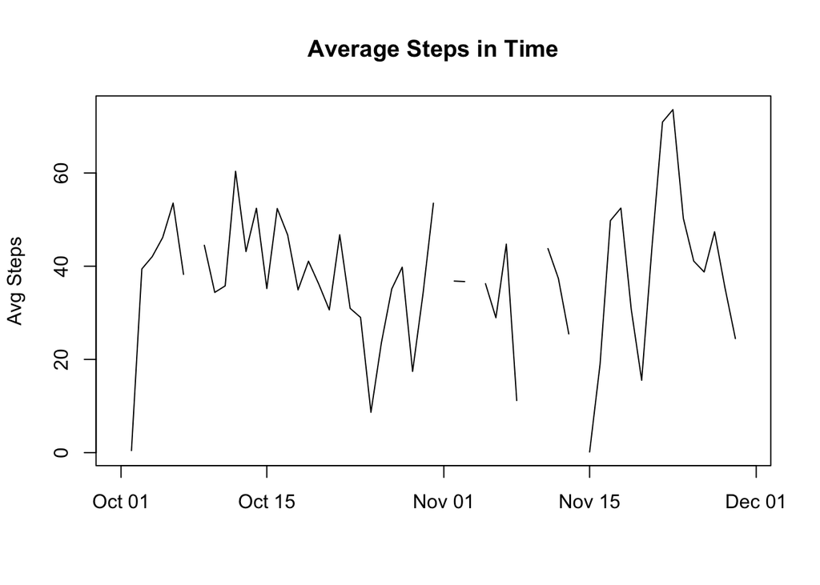

```r
AvgStp <- with(actData, tapply(steps, date, mean, na.rm = T))
plot(AvgStp~as.Date(names(AvgStp)), main = "Average Steps in Time", type = "l", ylab = "Avg Steps", xlab = "")
```

## The 5-minute interval that, on average, contains the maximum number of steps

```r
actData$interval <- as.factor(actData$interval)
AvgStpFreq <- with(actData, tapply(steps, interval, mean, na.rm = T))
max <- AvgStpFreq[which.max(AvgStpFreq)[[1]]]
max
```

```
##      835
## 206.1698
```

On average in all days the interval 835 had a maximum number of steps of 206.1698113

## Code to describe and show a strategy for imputing missing data.

The following code loops over each observation in ‘steps’ and, if it’s NA, replaces the observation with the mean of all the observation with the same interval.

```r
c <- colSums(is.na(actData))
for (i in 1:nrow(actData)) {
        if (is.na(actData$steps[i])) {
                int <- as.numeric(as.character(actData$interval[i]))
                actData$steps[i] <- mean(subset(actData, interval == int)$steps, na.rm = T)
        }
}
```

Intially, before imputing NA for mean values, the numer of rows with NA was of 2304

## Histogram of the total number of steps taken each day after missing values are imputed

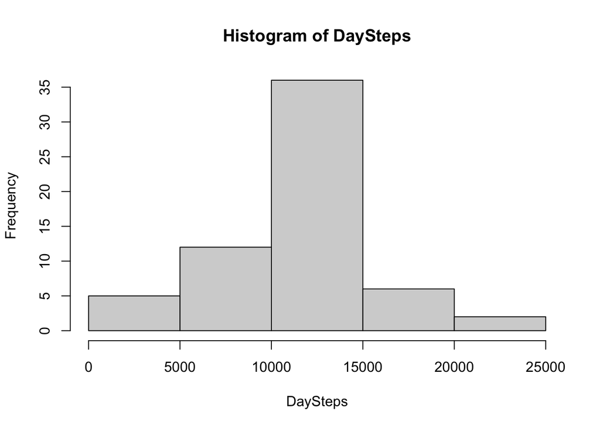

```r
DaySteps <- with(actData, tapply(steps, date, sum))
hist(DaySteps)
```

```r
sum2 <- summary(DaySteps)
```

With the summary calculate abvoce we’ll calculate it’s difference with the non-imputed dataset.

```r
sumdif <- c()
for (i in 1:length(sum)) {
        sumdif[i] <- sum2[i]-sum[i]
}
names(sumdif) <- names(sum)
sumdif
```

```
##      Min.   1st Qu.    Median      Mean   3rd Qu.      Max.
##   41.0000 3041.0000  371.1887 1411.9592    0.0000    0.0000
```

It’s observed that the minimum, 1st quartile, median and mean increased after imputing the missing values.

## Panel plot comparing the average number of steps taken per 5-minute interval across weekdays and weekends

First we create a variable indicating weather day is a weekday or weekend.

```r
actData$weekday <- factor(weekdays(actData$date))
for (i in 1:nrow(actData)) {
        if (actData$weekday[i] == "Sunday") {
                actData$Type[i] <- "Weekend"
        }
        else if (actData$weekday[i] == "Saturday") {
                actData$Type[i] <- "Weekend"
        }
        else {
                actData$Type[i] <- "Weekday"
        }
}
```

Now we group the data and plot it using the new variable type as a facet.

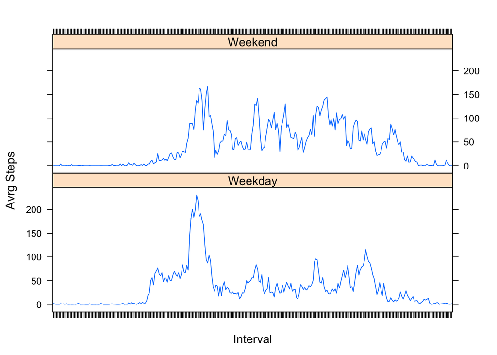

```r
library(lattice)
DatSteps <- aggregate(steps~ interval + Type, data = actData, mean)
xyplot(steps~interval | Type, data = DatSteps, type = "l", ylab = "Avrg Steps", xlab = "Interval", scales = list(x = list(cex = 0)), layout = c(1,2))
```

We see that on week days there were more steps(avrg) at lower intervals than on weekend. This may signify that on weekday this person walked more on the mornings than on afternoos. On the other hand on weekends there was less activity on the morning and more in the afternoon.